# Relationships among many variables

Danny Kaplan

Data Computing

We have spent most of our time on two subjects:

1. Data visualization
2. Data wrangling: getting from the data you are given to the “glyph-ready” data that you need to make a graphic or some other mode to guide interpretation of the data.

Visualization works well with 1-3 variables, and in some situations can work with more variables.

# A multivariable graphic

[figure not shown]

Glyph: `geom_ribbon()` or “Sankey”, Annotations: rivers and towns

Aesthetics: `(x,y)` latitude and longitude; `size` size of army; `color` advance or retreat.

[source](http://www.edwardtufte.com/tufte/graphics/minard_lg.gif)

# With more variables?

If we need to relate more variables, a visualization may not suffice.

Formal mathematical representations provide an alternative:

- model formulas, e.g. `lm()`
- other structures for models, e.g. regression or classification trees.

# Example: Child carseat sales

Purpose: Figure out how to raise sales of a brand of carseats.

```r
head(ISLR::Carseats %>% rename(CompP=CompPrice,Ads=Advertising, Pop=Population, Shelf=ShelveLoc, Edu=Education))
```

| Sales | CompP | Income | Ads | Pop | Price | Shelf | Age | Edu | Urban | US |
| --- | --- | --- | --- | --- | --- | --- | --- | --- | --- | --- |
| 9.50 | 138 | 73 | 11 | 276 | 120 | Bad | 42 | 17 | Yes | Yes |
| 11.22 | 111 | 48 | 16 | 260 | 83 | Good | 65 | 10 | Yes | Yes |
| 10.06 | 113 | 35 | 10 | 269 | 80 | Medium | 59 | 12 | Yes | Yes |
| 7.40 | 117 | 100 | 4 | 466 | 97 | Medium | 55 | 14 | Yes | Yes |
| 4.15 | 141 | 64 | 3 | 340 | 128 | Bad | 38 | 13 | Yes | No |
| 10.81 | 124 | 113 | 13 | 501 | 72 | Bad | 78 | 16 | No | Yes |

# Hypothesis generated model

1. Price relative to competitor’s price is relevant.
2. Larger population gives larger sales
3. Education level?
4. Advertising?

```r
Carseats <-
  ISLR::Carseats %>%
  mutate(rel_price = Price / CompPrice)
mod1 <-
  Carseats %>%
  lm(Sales ~ rel_price + Population + Education + Advertising,
     data = .)
coef(mod1)
```

```
##   (Intercept)     rel_price    Population     Education   Advertising
##  17.497352098 -10.907759402  -0.000139262  -0.055051345   0.136911760
```

# Interpreting the model?

```r
summary(mod1)
```

```
##
## Call:
## lm(formula = Sales ~ rel_price + Population + Education + Advertising,
##     data = .)
##
## Residuals:
##    Min     1Q Median     3Q    Max
## -6.005 -1.470 -0.118  1.310  5.280
##
## Coefficients:
##               Estimate Std. Error t value Pr(>|t|)
## (Intercept)  1.750e+01  8.728e-01  20.048  < 2e-16 ***
## rel_price   -1.091e+01  6.673e-01 -16.345  < 2e-16 ***
## Population  -1.393e-04  7.470e-04  -0.186    0.852
## Education   -5.505e-02  4.051e-02  -1.359    0.175
## Advertising  1.369e-01  1.651e-02   8.294 1.74e-15 ***
## ---
## Signif. codes:  0 '***' 0.001 '**' 0.01 '*' 0.05 '.' 0.1 ' ' 1
##
## Residual standard error: 2.108 on 395 degrees of freedom
## Multiple R-squared:  0.4483, Adjusted R-squared:  0.4427
## F-statistic: 80.25 on 4 and 395 DF,  p-value: < 2.2e-16
```

# Another formalism: Regression trees

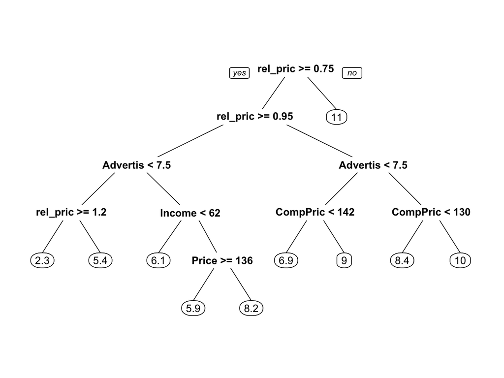

```r
library(rpart)
mod2 <-
  Carseats %>%
  rpart(Sales ~ rel_price + Price + CompPrice + Advertising + Population + Education + Income, data=.)
prp(mod2)
```

# No prior model at all?

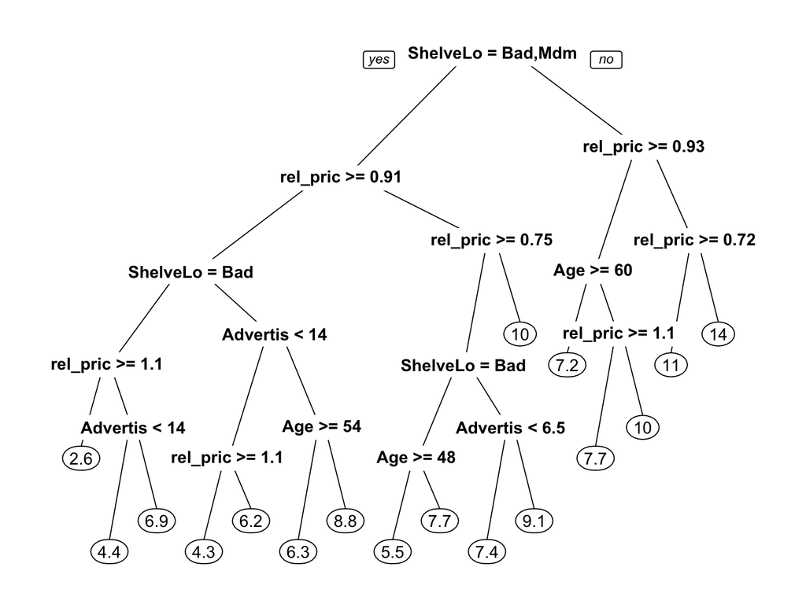

```r
mod3 <- Carseats %>% rpart(Sales ~ ., data=.)
prp(mod3)
```

# Shelf location?

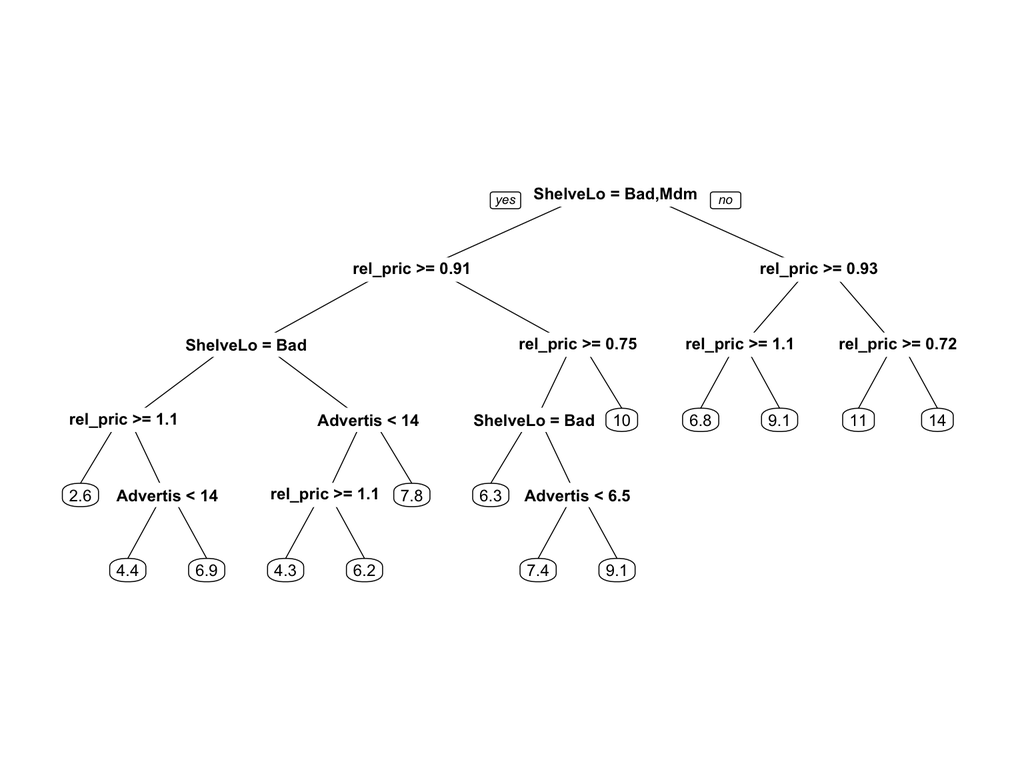

```r
mod4 <- Carseats %>%
  rpart(Sales ~ rel_price + Advertising + ShelveLoc + Population, data=.)
prp(mod4)
```

# Building a classifier

> 62 variables are derived from a confocal laser scanning image of the optic nerve head, describing its morphology. Observations are from normal and glaucomatous eyes, respectively.

```r
data("GlaucomaM", package = "TH.data")
```

### With glaucoma

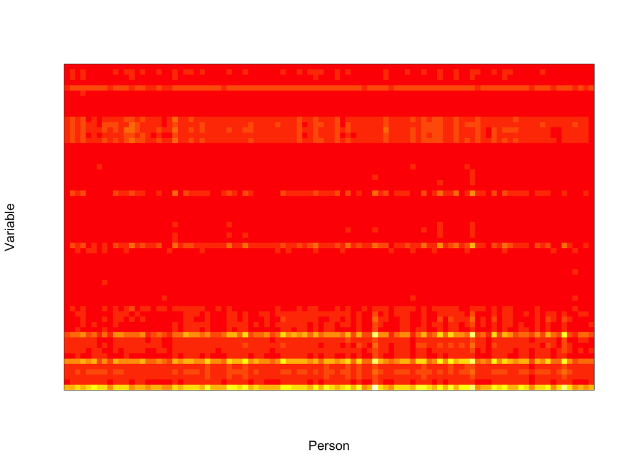

### Normal eyes

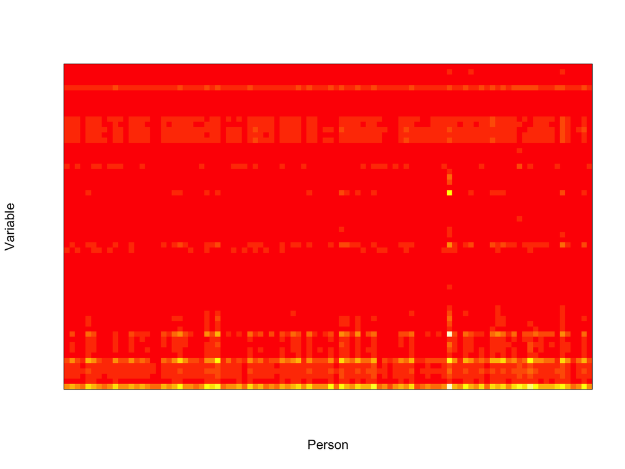

# Build a classifier …

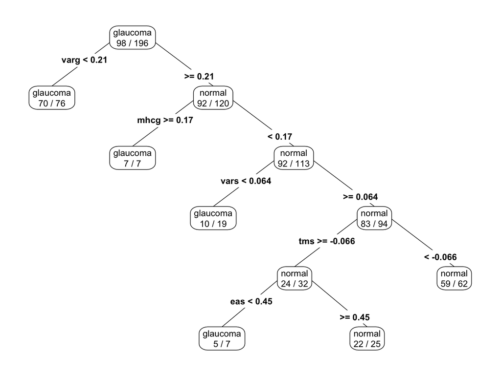

```r
glaucoma_rpart <- rpart(Class ~ ., data = GlaucomaM,
                        control = rpart.control(xval = 100))
prp(glaucoma_rpart, type=4, extra=2)
```

# Unsupervised learning

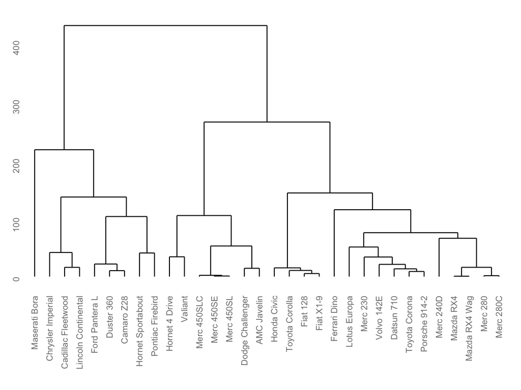

```r
Dists <- dist(mtcars)
Dendrogram <- hclust(Dists)
ggdendrogram(Dendrogram)
```

# Important Machine Learning concepts

1. Cross-validation
2. Supervised vs unsupervised learning
3. Recursive partitioning
4. Dimension reduction